# Bias in EPSRC Peer Review - Research Question 19

Status: Final

Contributors: Ged Hiscoke & Dakota Langhals, Royal Statistical Society

Version: 2025-03-05 16:16:08

## Data Preparation

```r
###################################################
## Set up Data for Unique Individuals by Theme
###################################################
# Applicants By Theme -----------------------------------------------------
df<- EPSRC$Grants.df %>% select(AnonPROJ, AnonTHM)
df <- df %>%
  left_join(
    EPSRC$Investigators.df %>% select(
      Sex,
      EthnicityBinary,
      Disability,
      NationalityBinary,
      AgeRange,
      AnonINV,
      AnonPROJ
    ),
    by = "AnonPROJ"
  )

Q19thmApplicants.df <- df %>%
  select(-AnonPROJ) %>%                      # Drop the AnonPROJ column
  group_by(AnonTHM) %>%
  distinct(AnonINV, .keep_all = TRUE) %>%    # Count applicants only once per theme
  ungroup()


# Awardees by Theme -------------------------------------------------------

df<- EPSRC$Grants.df %>% filter(GrantOutcome=="Funded") %>%select(AnonPROJ, AnonTHM)
df <- df %>%
  left_join(
    EPSRC$Investigators.df %>% select(
      Sex,
      EthnicityBinary,
      Disability,
      NationalityBinary,
      AgeRange,
      AnonINV,
      AnonPROJ
    ),
    by = "AnonPROJ"
  )

Q19thmAwardees.df <- df %>%
  select(-AnonPROJ) %>%                      # Drop the AnonPROJ column
  group_by(AnonTHM) %>%
  distinct(AnonINV, .keep_all = TRUE) %>%    # Count awardees only once per theme
  ungroup()


# Reviewers by Theme ------------------------------------------------------


df <- EPSRC$Grants.df %>% select(AnonPROJ, AnonTHM)
df <- df %>%
  right_join(
    EPSRC$Reviewers.df %>% select(
      Sex,
      EthnicityBinary,
      Disability,
      NationalityBinary,
      AgeRange,
      AnonREV,
      AnonPROJ
    ),
    by = "AnonPROJ"
  )

Q19thmReviewers.df <- df %>%
  select(-AnonPROJ) %>%                      # Drop the AnonPROJ column
  group_by(AnonTHM) %>%
  distinct(AnonREV, .keep_all = TRUE) %>%    # Count reviewers only once per theme
  ungroup()


# Panelists by Theme ---------------------------------------------------------------
df<- EPSRC$Grants.df %>% select(AnonPROJ, AnonTHM)

### Get the meeting number
df <- df %>% right_join( EPSRC$GrantMeeting.df %>% select(AnonMTG, AnonPROJ ),by = "AnonPROJ" )
df <- df %>% right_join( EPSRC$MeetingParticipants.df%>% select(AnonMTG,
                                                                Sex,
                                                                EthnicityBinary,
                                                                Disability,
                                                                NationalityBinary,
                                                                AgeRange,
                                                                AnonPNL
                                                                ),
                                                                by = "AnonMTG" )

### Eliminate Duplicates
Q19thmPanelists.df <- df %>%
  select(-AnonMTG, -AnonPROJ) %>%                      # Drop the AnonPROJ column
  group_by(AnonTHM) %>%
  distinct(AnonPNL, .keep_all = TRUE) %>%    # Count panelists only once per theme
  ungroup()



###################################################
##Set up Data for Unique Individuals by RAG
###################################################
# Applicants By RAG -----------------------------------------------------
df<- EPSRC$Grants.df %>% select(AnonPROJ)
df <- df %>% right_join(EPSRC$ResearchAreas.df %>% select(
                                                          AnonPROJ,
                                                          AnonRAG,
                                                          RAFraction),
                                                          by = "AnonPROJ")

df <- df %>%
  group_by(AnonPROJ) %>%
  filter(RAFraction == max(RAFraction)) %>%
  distinct(AnonRAG, .keep_all = TRUE) %>%
  ungroup()


df <- df %>%
  left_join(
    EPSRC$Investigators.df %>% select(
      Sex,
      EthnicityBinary,
      Disability,
      NationalityBinary,
      AgeRange,
      AnonINV,
      AnonPROJ
    ),
    by = "AnonPROJ"
  )



Q19RAGApplicants.df <- df %>%
  select(-AnonPROJ) %>%                      # Drop the AnonPROJ column
  group_by(AnonRAG) %>%
  distinct(AnonINV, .keep_all = TRUE) %>%    # Count applicants only once per research area
  ungroup()


# Awardees by RAG -------------------------------------------------------

df<- EPSRC$Grants.df %>% filter(GrantOutcome =="Funded") %>% select(AnonPROJ)
df <- df %>% inner_join(EPSRC$ResearchAreas.df %>% select(
  AnonPROJ,
  AnonRAG,
  RAFraction),
  by = "AnonPROJ")

df <- df %>%
  group_by(AnonPROJ) %>%
  filter(RAFraction == max(RAFraction)) %>%
  distinct(AnonRAG, .keep_all = TRUE) %>%
  ungroup()

df <- df %>%
  left_join(
    EPSRC$Investigators.df %>% select(
      Sex,
      EthnicityBinary,
      Disability,
      NationalityBinary,
      AgeRange,
      AnonINV,
      AnonPROJ
    ),
    by = "AnonPROJ"
  )

Q19RAGAwardees.df <- df %>%
  select(-AnonPROJ) %>%                      # Drop the AnonPROJ column
  group_by(AnonRAG) %>%
  distinct(AnonINV, .keep_all = TRUE) %>%    # Count awardees only once per RAG
  ungroup()


# Reviewers by RAG ------------------------------------------------------


df <- EPSRC$Grants.df %>% select(AnonPROJ)
df <- df %>% right_join(EPSRC$ResearchAreas.df %>% select(
  AnonPROJ,
  AnonRAG,
  RAFraction),
  by = "AnonPROJ")

df <- df %>%
  group_by(AnonPROJ) %>%
  filter(RAFraction == max(RAFraction)) %>%
  distinct(AnonRAG, .keep_all = TRUE) %>%
  ungroup()

df <- df %>%
  right_join(
    EPSRC$Reviewers.df %>% select(
      Sex,
      EthnicityBinary,
      Disability,
      NationalityBinary,
      AgeRange,
      AnonREV,
      AnonPROJ
    ),
    by = "AnonPROJ"
  )

Q19RAGReviewers.df <- df %>%
  select(-AnonPROJ) %>%                      # Drop the AnonPROJ column
  group_by(AnonRAG) %>%
  distinct(AnonREV, .keep_all = TRUE) %>%    # Count reviewers only once per RAG
  ungroup()


# Panelists by RAG ---------------------------------------------------------------
df<- EPSRC$Grants.df %>% select(AnonPROJ)
```

```r
df <- df %>% right_join(EPSRC$ResearchAreas.df %>% select(
  AnonPROJ,
  AnonRAG,
  RAFraction),
  by = "AnonPROJ")

df <- df %>%
  group_by(AnonPROJ) %>%
  filter(RAFraction == max(RAFraction)) %>%
  distinct(AnonRAG, .keep_all = TRUE) %>%
  ungroup()


### Get the meeting number
df <- df %>% right_join( EPSRC$GrantMeeting.df %>% select(AnonMTG, AnonPROJ ),by = "AnonPROJ" )
df <- df %>% right_join( EPSRC$MeetingParticipants.df%>% select(AnonMTG,
                                                                Sex,
                                                                EthnicityBinary,
                                                                Disability,
                                                                NationalityBinary,
                                                                AgeRange,
                                                                AnonPNL
),
by = "AnonMTG" )

### Eliminate Duplicates
Q19RAGPanelists.df <- df %>%
  select(-AnonMTG, -AnonPROJ) %>%                      # Drop the AnonPROJ column
  group_by(AnonRAG) %>%
  distinct(AnonPNL, .keep_all = TRUE) %>%    # Count panelists only once per RAG
  ungroup()



### Adding intersectional sex with ethnicity
Q19RAGApplicants.df$Sex_Ethnicity <- interaction(Q19RAGApplicants.df$Sex, Q19RAGApplicants.df$EthnicityBinary)
Q19RAGAwardees.df$Sex_Ethnicity <- interaction(Q19RAGAwardees.df$Sex, Q19RAGAwardees.df$EthnicityBinary)
Q19RAGPanelists.df$Sex_Ethnicity <- interaction(Q19RAGPanelists.df$Sex, Q19RAGPanelists.df$EthnicityBinary)
Q19RAGReviewers.df$Sex_Ethnicity <- interaction(Q19RAGReviewers.df$Sex, Q19RAGReviewers.df$EthnicityBinary)

Q19thmApplicants.df$Sex_Ethnicity <- interaction(Q19thmApplicants.df$Sex, Q19thmApplicants.df$EthnicityBinary)
Q19thmAwardees.df$Sex_Ethnicity <- interaction(Q19thmAwardees.df$Sex, Q19thmAwardees.df$EthnicityBinary)
Q19thmPanelists.df$Sex_Ethnicity <- interaction(Q19thmPanelists.df$Sex, Q19thmPanelists.df$EthnicityBinary)
Q19thmReviewers.df$Sex_Ethnicity <- interaction(Q19thmReviewers.df$Sex, Q19thmReviewers.df$EthnicityBinary)


#Getting AgeRangeCollapsed
Q19RAGApplicants.df <- Q19RAGApplicants.df %>%
  mutate(AgeRangeCollapsed = case_when(AgeRange == "25 and Under" ~ "35 and Under",
                                       AgeRange == "26-35" ~ "35 and Under",
                                       AgeRange == "36-45" ~ "36-55",
                                       AgeRange == "46-55" ~ "36-55",
                                       AgeRange == "56-65" ~ "56 and Over",
                                       AgeRange == "66+" ~  "56 and Over"))

Q19RAGAwardees.df <- Q19RAGAwardees.df %>%
  mutate(AgeRangeCollapsed = case_when(AgeRange == "25 and Under" ~ "35 and Under",
                                       AgeRange == "26-35" ~ "35 and Under",
                                       AgeRange == "36-45" ~ "36-55",
                                       AgeRange == "46-55" ~ "36-55",
                                       AgeRange == "56-65" ~ "56 and Over",
                                       AgeRange == "66+" ~  "56 and Over"))

Q19RAGPanelists.df <- Q19RAGPanelists.df %>%
  mutate(AgeRangeCollapsed = case_when(AgeRange == "25 and Under" ~ "35 and Under",
                                       AgeRange == "26-35" ~ "35 and Under",
                                       AgeRange == "36-45" ~ "36-55",
                                       AgeRange == "46-55" ~ "36-55",
                                       AgeRange == "56-65" ~ "56 and Over",
                                       AgeRange == "66+" ~  "56 and Over"))

Q19RAGReviewers.df <- Q19RAGReviewers.df %>%
  mutate(AgeRangeCollapsed = case_when(AgeRange == "25 and Under" ~ "35 and Under",
                                       AgeRange == "26-35" ~ "35 and Under",
                                       AgeRange == "36-45" ~ "36-55",
                                       AgeRange == "46-55" ~ "36-55",
                                       AgeRange == "56-65" ~ "56 and Over",
                                       AgeRange == "66+" ~  "56 and Over"))




Q19thmApplicants.df <- Q19thmApplicants.df %>%
  mutate(AgeRangeCollapsed = case_when(AgeRange == "25 and Under" ~ "35 and Under",
                                       AgeRange == "26-35" ~ "35 and Under",
                                       AgeRange == "36-45" ~ "36-55",
                                       AgeRange == "46-55" ~ "36-55",
                                       AgeRange == "56-65" ~ "56 and Over",
                                       AgeRange == "66+" ~  "56 and Over"))

Q19thmAwardees.df <- Q19thmAwardees.df %>%
  mutate(AgeRangeCollapsed = case_when(AgeRange == "25 and Under" ~ "35 and Under",
                                       AgeRange == "26-35" ~ "35 and Under",
                                       AgeRange == "36-45" ~ "36-55",
                                       AgeRange == "46-55" ~ "36-55",
                                       AgeRange == "56-65" ~ "56 and Over",
                                       AgeRange == "66+" ~  "56 and Over"))

Q19thmPanelists.df <- Q19thmPanelists.df %>%
  mutate(AgeRangeCollapsed = case_when(AgeRange == "25 and Under" ~ "35 and Under",
                                       AgeRange == "26-35" ~ "35 and Under",
                                       AgeRange == "36-45" ~ "36-55",
                                       AgeRange == "46-55" ~ "36-55",
                                       AgeRange == "56-65" ~ "56 and Over",
                                       AgeRange == "66+" ~  "56 and Over"))

Q19thmReviewers.df <- Q19thmReviewers.df %>%
  mutate(AgeRangeCollapsed = case_when(AgeRange == "25 and Under" ~ "35 and Under",
                                       AgeRange == "26-35" ~ "35 and Under",
                                       AgeRange == "36-45" ~ "36-55",
                                       AgeRange == "46-55" ~ "36-55",
                                       AgeRange == "56-65" ~ "56 and Over",
                                       AgeRange == "66+" ~  "56 and Over"))
```

```r
## For the purposes of the report, EPSRC requested not having gaps between the presented RAGs. These organically arise in two places - RAG-04 is their NULL RAG, and was not included in the raw data. RAG-01 has too few observations in the raw data to reasonably analyse.

Q19RAGApplicants.df <- Q19RAGApplicants.df %>% filter(AnonRAG != "RAG-01") %>%
  mutate(AnonRAG = case_when(AnonRAG == "RAG-02" ~ "RAG-01",
                             AnonRAG == "RAG-03" ~ "RAG-02",
                             AnonRAG == "RAG-05" ~ "RAG-03",
                             AnonRAG == "RAG-06" ~ "RAG-04",
                             AnonRAG == "RAG-07" ~ "RAG-05",
                             AnonRAG == "RAG-08" ~ "RAG-06",
                             AnonRAG == "RAG-09" ~ "RAG-07",
                             AnonRAG == "RAG-10" ~ "RAG-08",
                             AnonRAG == "RAG-11" ~ "RAG-09",
                             TRUE ~ AnonRAG))

Q19RAGAwardees.df <- Q19RAGAwardees.df %>% filter(AnonRAG != "RAG-01") %>%
  mutate(AnonRAG = case_when(AnonRAG == "RAG-02" ~ "RAG-01",
                             AnonRAG == "RAG-03" ~ "RAG-02",
                             AnonRAG == "RAG-05" ~ "RAG-03",
                             AnonRAG == "RAG-06" ~ "RAG-04",
                             AnonRAG == "RAG-07" ~ "RAG-05",
                             AnonRAG == "RAG-08" ~ "RAG-06",
                             AnonRAG == "RAG-09" ~ "RAG-07",
                             AnonRAG == "RAG-10" ~ "RAG-08",
                             AnonRAG == "RAG-11" ~ "RAG-09",
                             TRUE ~ AnonRAG))

Q19RAGPanelists.df <- Q19RAGPanelists.df %>% filter(AnonRAG != "RAG-01") %>%
  mutate(AnonRAG = case_when(AnonRAG == "RAG-02" ~ "RAG-01",
                             AnonRAG == "RAG-03" ~ "RAG-02",
                             AnonRAG == "RAG-05" ~ "RAG-03",
                             AnonRAG == "RAG-06" ~ "RAG-04",
                             AnonRAG == "RAG-07" ~ "RAG-05",
                             AnonRAG == "RAG-08" ~ "RAG-06",
                             AnonRAG == "RAG-09" ~ "RAG-07",
                             AnonRAG == "RAG-10" ~ "RAG-08",
                             AnonRAG == "RAG-11" ~ "RAG-09",
                             TRUE ~ AnonRAG))

Q19RAGReviewers.df <- Q19RAGReviewers.df %>% filter(AnonRAG != "RAG-01") %>%
  mutate(AnonRAG = case_when(AnonRAG == "RAG-02" ~ "RAG-01",
                             AnonRAG == "RAG-03" ~ "RAG-02",
                             AnonRAG == "RAG-05" ~ "RAG-03",
                             AnonRAG == "RAG-06" ~ "RAG-04",
                             AnonRAG == "RAG-07" ~ "RAG-05",
                             AnonRAG == "RAG-08" ~ "RAG-06",
                             AnonRAG == "RAG-09" ~ "RAG-07",
                             AnonRAG == "RAG-10" ~ "RAG-08",
                             AnonRAG == "RAG-11" ~ "RAG-09",
                             TRUE ~ AnonRAG))
```

```r
##Function-----------------------------------------
# Function to calculate bootstrap CI for proportions
boot_ci <- function(data, indices) {
  sampled_data <- data[indices]
  prop <- mean(sampled_data)
  return(prop)
}

# Function to compute bootstrapped confidence intervals
compute_ci <- function(data) {
  if (length(data) < 2) {
    return(data.frame(CI_Lower = NA, CI_Upper = NA))
  }

  boot_result <- boot(data, boot_ci, R = 1000)
  ci <- boot.ci(boot_result, type = "basic")
  return(data.frame(CI_Lower = ci$basic[4], CI_Upper = ci$basic[5]))
}

# Generalized function to compute counts, proportions, and CIs by group and demographic
compute_statistics <- function(df, group_col, demo_col) {
  df <- df %>%
    rename(Group = !!sym(group_col), Demographic = !!sym(demo_col))

  groups <- unique(df$Group)
  results_list <- list()

  for (group in groups) {
    group_df <- df %>% filter(Group == group)

    result <- group_df %>%
      group_by(Demographic) %>%
      summarise(
        Count = n(),
        Proportion = Count / nrow(group_df)
      ) %>%
      ungroup() %>%
      rowwise() %>%
      mutate(
        CI = list(compute_ci(group_df$Demographic == Demographic)),
        CI_L = CI$CI_Lower,
        CI_U = CI$CI_Upper
      ) %>%
      select(-CI) %>%
      ungroup() %>%
      mutate(Theme = group)

    results_list[[group]] <- result
  }

  results_df <- bind_rows(results_list)
  results_df <- bind_rows(results_list) %>%
    mutate(Group = demo_col)

  return(results_df)
}
```

```r
# Function to round columns as specified
round_columns <- function(df) {
  df <- df %>%
    mutate(
      Count = ifelse(Count < 6, "\u22645", round(Count / 5) * 5),
      across(where(is.numeric) & !c(Count), ~ ifelse(Count == "\u22645", "~", round(., 1)))
    )
  return(df)
}
```

## Applicants

#### Table 19.01 Counts, Proportions, and Confidence Intervals for Demographic Proportions by Research Area, Applicants

```r
## Applicants conf-int Table

df_sex <- Q19RAGApplicants.df %>% filter(Sex != "Unknown" & Sex != "Not Disclosed")
df_ethnicity <- Q19RAGApplicants.df %>% filter(EthnicityBinary != "Unknown" & EthnicityBinary != "Not Disclosed")
df_nationality <- Q19RAGApplicants.df %>% filter(NationalityBinary != "Unknown" & NationalityBinary != "Not Disclosed")
df_disability <- Q19RAGApplicants.df %>% filter(Disability != "Unknown" & Disability != "Not Disclosed")
df_sex_ethnicity <- Q19RAGApplicants.df %>% filter(!str_detect(Sex_Ethnicity, "Unknown|Not Disclosed"))
df_age <- Q19RAGApplicants.df %>% filter(!str_detect(AgeRangeCollapsed, "Unknown|Not Disclosed"), !is.na(AgeRangeCollapsed))



t3 <- compute_statistics(df_sex, "AnonRAG", "Sex")
t3 <- rbind(t3,compute_statistics(df_ethnicity, "AnonRAG", "EthnicityBinary"))
t3 <- rbind(t3,compute_statistics(df_nationality, "AnonRAG", "NationalityBinary"))
t3 <- rbind(t3,compute_statistics(df_disability, "AnonRAG", "Disability"))
t3 <- rbind(t3, compute_statistics(df_age, "AnonRAG", "AgeRangeCollapsed"))

table19.01 <- t3 %>%
  mutate(Count = if_else(Count < 30, "<30", as.character(round(Count / 10) * 10)))

kable(table19.01)
```

| Demographic | Count | Proportion | CI_L | CI_U | Theme | Group |
| --- | --- | --- | --- | --- | --- | --- |
| Female | 1100 | 0.1842193 | 0.1741935 | 0.1942452 | RAG-09 | Sex |
| Male | 4880 | 0.8157807 | 0.8060849 | 0.8259779 | RAG-09 | Sex |
| Female | 1630 | 0.2268357 | 0.2166679 | 0.2361676 | RAG-07 | Sex |
| Male | 5550 | 0.7731643 | 0.7629964 | 0.7837501 | RAG-07 | Sex |
| Female | 1450 | 0.1981184 | 0.1884374 | 0.2075231 | RAG-02 | Sex |
| Male | 5880 | 0.8018816 | 0.7930223 | 0.8112899 | RAG-02 | Sex |
| Female | 620 | 0.1906663 | 0.1774717 | 0.2047897 | RAG-06 | Sex |
| Male | 2640 | 0.8093337 | 0.7958244 | 0.8225361 | RAG-06 | Sex |
| Female | 660 | 0.2060286 | 0.1917498 | 0.2209368 | RAG-05 | Sex |
| Male | 2560 | 0.7939714 | 0.7803062 | 0.8082660 | RAG-05 | Sex |
| Female | 1130 | 0.2596837 | 0.2461725 | 0.2725073 | RAG-01 | Sex |
| Male | 3230 | 0.7403163 | 0.7281745 | 0.7529223 | RAG-01 | Sex |
| Female | 720 | 0.1846905 | 0.1728744 | 0.1972772 | RAG-08 | Sex |
| Male | 3170 | 0.8153095 | 0.8029862 | 0.8268687 | RAG-08 | Sex |
| Female | 930 | 0.2466984 | 0.2327061 | 0.2609614 | RAG-04 | Sex |
| Male | 2850 | 0.7533016 | 0.7387811 | 0.7680930 | RAG-04 | Sex |
| Female | 80 | 0.1197512 | 0.0933521 | 0.1430793 | RAG-03 | Sex |
| Male | 570 | 0.8802488 | 0.8553655 | 0.9082426 | RAG-03 | Sex |
| Ethnic Minority | 810 | 0.1436893 | 0.1348632 | 0.1519859 | RAG-09 | EthnicityBinary |
| White | 4850 | 0.8563107 | 0.8469550 | 0.8653133 | RAG-09 | EthnicityBinary |
| Ethnic Minority | 1410 | 0.2093884 | 0.1990227 | 0.2191619 | RAG-07 | EthnicityBinary |
| White | 5340 | 0.7906116 | 0.7808457 | 0.7999408 | RAG-07 | EthnicityBinary |
| Ethnic Minority | 1450 | 0.2072717 | 0.1963964 | 0.2167192 | RAG-02 | EthnicityBinary |
| White | 5540 | 0.7927283 | 0.7828551 | 0.8027447 | RAG-02 | EthnicityBinary |
| Ethnic Minority | 540 | 0.1764514 | 0.1617743 | 0.1904762 | RAG-06 | EthnicityBinary |
| White | 2520 | 0.8235486 | 0.8091977 | 0.8375651 | RAG-06 | EthnicityBinary |
| Ethnic Minority | 690 | 0.2238758 | 0.2096409 | 0.2390812 | RAG-05 | EthnicityBinary |
| White | 2400 | 0.7761242 | 0.7615658 | 0.7916532 | RAG-05 | EthnicityBinary |
| Ethnic Minority | 790 | 0.1908195 | 0.1790435 | 0.2030701 | RAG-01 | EthnicityBinary |
| White | 3370 | 0.8091805 | 0.7978851 | 0.8202355 | RAG-01 | EthnicityBinary |

[output cut: 69 more lines]

#### Figure 19.01 Plot of Proportions, and Confidence Intervals for Demographic Proportions by Research Area, Applicants

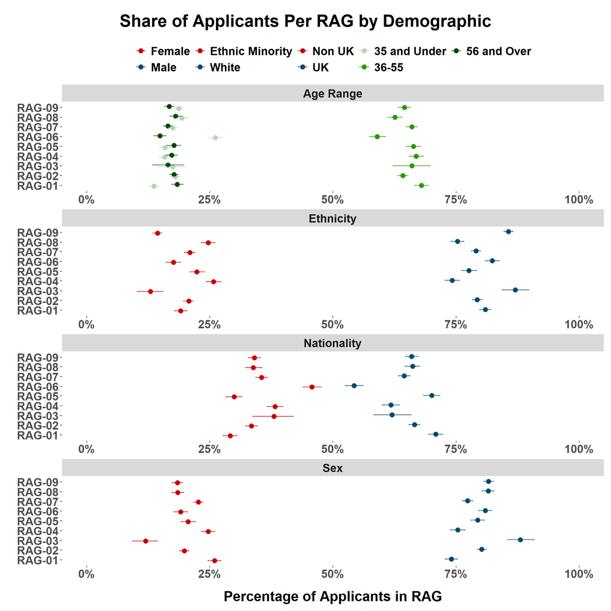

```r
### Applicants
plot_colors <-
  c(
    "Male"= RSSblue,
    "Female"= RSSred,
    "UK"=RSSblue,
    "Non UK"=RSSred,
    "Known Disability"=RSSblue   ,
    "No Known Disability"=RSSred  ,
    "White"=RSSblue  ,
    "Ethnic Minority"=RSSred  ,
    "Unknown"=col_unknown  ,
    "Not Disclosed"=col_notdisclosed  ,
    "35 and Under" = col_age1,
    "36-55" = col_age3,
    "56 and Over" = col_age5,
    "Male.White"=RSSblue,
    "Female.White"=RSSred,
    "Male.Ethnic Minority"=RSSlightblue,
    "Female.Ethnic Minority"=RSSgold,
    "Other"=col_other
  )


t3 <- t3 %>% mutate(
  Group = case_when(
    Group == "EthnicityBinary" ~ "Ethnicity",
    Group == "AgeRangeCollapsed" ~ "Age Range",
    Group == "NationalityBinary" ~ "Nationality",
    TRUE ~ Group
  )
)

# Plot the CIs, faceted by Group, colored by Demographic, with dodged positions
fig19.01 <- ggplot(t3 %>% filter(Group != "Disability"), aes(x = Theme, y = Proportion, color = Demographic)) +
  geom_point(position = position_dodge(width = 0.3), size = 3) +
  geom_errorbar(aes(ymin = CI_L, ymax = CI_U),
                position = position_dodge(width = 0.3),
                width = 0.2) +

  facet_wrap(~ Group, ncol = 1, scales = 'free') +
  scale_color_manual(values = plot_colors) +
  labs(title = "Share of Applicants Per RAG by Demographic",
       x = element_blank(),
       y = "Percentage of Applicants in RAG") +
  scale_y_continuous(limits = c(0,1),
                     labels = scales::percent_format(accuracy = 1)) +

  theme(plot.title = element_text(size = 24, hjust = 0.5, margin = margin(b = 15), face = "bold"),
        plot.title.position = "plot",
        axis.title.x = element_text(size = 20, margin = margin(t = 15), face = "bold"),
        axis.title.y = element_text(size = 20, margin = margin(r = 10), face = "bold"),
        plot.margin = margin(t = 20, r = 10, b = 10, l = 10),
        axis.text.x = element_text(size = 16, face = "bold"),
        axis.text.y = element_text(size = 16, face = "bold"),
        legend.position = "top",
        legend.text = element_text(size = 16, face = "bold"),
        legend.title = element_blank(),
        panel.background = element_rect(fill = "white", color = NA),  # Set panel background to white
        plot.background = element_rect(fill = "white", color = NA),   # Set plot background to white
        #panel.grid.major = element_line(color = "gray90"),            # Optional: adjust grid color
        panel.grid.minor = element_blank(),
        strip.text = element_text(size = 16, face = "bold")
    ) +
  coord_flip()

print(fig19.01)
```

#### Table 19.02 Counts, Proportions, and Confidence Intervals for Demographic Proportions by Theme, Applicants

```r
## Applicants conf-int Table

df_sex <- Q19thmApplicants.df %>% filter(Sex != "Unknown" & Sex != "Not Disclosed")
df_ethnicity <- Q19thmApplicants.df %>% filter(EthnicityBinary != "Unknown" & EthnicityBinary != "Not Disclosed")
df_nationality <- Q19thmApplicants.df %>% filter(NationalityBinary != "Unknown" & NationalityBinary != "Not Disclosed")
df_disability <- Q19thmApplicants.df %>% filter(Disability != "Unknown" & Disability != "Not Disclosed")
df_sex_ethnicity <- Q19thmApplicants.df %>% filter(!str_detect(Sex_Ethnicity, "Unknown|Not Disclosed"))
df_age <- Q19thmApplicants.df %>% filter(!str_detect(AgeRangeCollapsed, "Unknown|Not Disclosed"), !is.na(AgeRangeCollapsed))




t3 <- compute_statistics(df_sex, "AnonTHM", "Sex")
t3 <- rbind(t3,compute_statistics(df_ethnicity, "AnonTHM", "EthnicityBinary"))
t3 <- rbind(t3,compute_statistics(df_nationality, "AnonTHM", "NationalityBinary"))
t3 <- rbind(t3,compute_statistics(df_disability, "AnonTHM", "Disability"))
```

```
## [1] "All values of t are equal to  1 \n Cannot calculate confidence intervals"
## [1] "All values of t are equal to  1 \n Cannot calculate confidence intervals"
## [1] "All values of t are equal to  1 \n Cannot calculate confidence intervals"
```

```r
t3 <- rbind(t3, compute_statistics(df_age, "AnonTHM", "AgeRangeCollapsed"))


table19.02 <- t3 %>%
  mutate(Count = if_else(Count < 30, "<30", as.character(round(Count / 10) * 10)))

kable(table19.02)
```

| Demographic | Count | Proportion | CI_L | CI_U | Theme | Group |
| --- | --- | --- | --- | --- | --- | --- |
| Female | 720 | 0.1668609 | 0.1552086 | 0.1775751 | THM-17 | Sex |
| Male | 3580 | 0.8331391 | 0.8212538 | 0.8443194 | THM-17 | Sex |
| Female | 760 | 0.1821872 | 0.1707319 | 0.1931710 | THM-13 | Sex |
| Male | 3420 | 0.8178128 | 0.8054024 | 0.8290353 | THM-13 | Sex |
| Female | 1030 | 0.1861982 | 0.1765984 | 0.1967035 | THM-07 | Sex |
| Male | 4490 | 0.8138018 | 0.8033011 | 0.8252036 | THM-07 | Sex |
| Female | 350 | 0.1725318 | 0.1564027 | 0.1881720 | THM-20 | Sex |
| Male | 1690 | 0.8274682 | 0.8118280 | 0.8440860 | THM-20 | Sex |
| Female | 1380 | 0.2416987 | 0.2303435 | 0.2532331 | THM-18 | Sex |
| Male | 4340 | 0.7583013 | 0.7472956 | 0.7696476 | THM-18 | Sex |
| Female | 490 | 0.1792453 | 0.1643687 | 0.1948476 | THM-21 | Sex |
| Male | 2260 | 0.8207547 | 0.8066130 | 0.8356221 | THM-21 | Sex |
| Female | 1240 | 0.2650654 | 0.2521982 | 0.2766405 | THM-06 | Sex |
| Male | 3430 | 0.7349346 | 0.7224962 | 0.7480163 | THM-06 | Sex |
| Female | 670 | 0.1840220 | 0.1710814 | 0.1983331 | THM-04 | Sex |
| Male | 2960 | 0.8159780 | 0.8038637 | 0.8292011 | THM-04 | Sex |
| Female | 350 | 0.1740428 | 0.1566385 | 0.1904525 | THM-15 | Sex |
| Male | 1660 | 0.8259572 | 0.8095475 | 0.8428642 | THM-15 | Sex |
| Female | 40 | 0.1538462 | 0.1153846 | 0.1958042 | THM-05 | Sex |
| Male | 240 | 0.8461538 | 0.8076923 | 0.8846154 | THM-05 | Sex |
| Female | 60 | 0.1578947 | 0.1218837 | 0.1966759 | THM-22 | Sex |
| Male | 300 | 0.8421053 | 0.8060942 | 0.8808864 | THM-22 | Sex |
| Female | 450 | 0.3207681 | 0.2958748 | 0.3449321 | THM-03 | Sex |
| Male | 960 | 0.6792319 | 0.6543385 | 0.7041252 | THM-03 | Sex |
| Female | 320 | 0.1849078 | 0.1653226 | 0.2010369 | THM-02 | Sex |
| Male | 1420 | 0.8150922 | 0.7960829 | 0.8346774 | THM-02 | Sex |
| Female | 80 | 0.2075472 | 0.1698113 | 0.2479784 | THM-11 | Sex |
| Male | 290 | 0.7924528 | 0.7520216 | 0.8355795 | THM-11 | Sex |
| Female | 60 | 0.1118881 | 0.0856643 | 0.1381119 | THM-01 | Sex |
| Male | 510 | 0.8881119 | 0.8636364 | 0.9160839 | THM-01 | Sex |

[output cut: 207 more lines]

#### Figure 19.02 Plot of Proportions, and Confidence Intervals for Demographic Proportions by Theme, Applicants

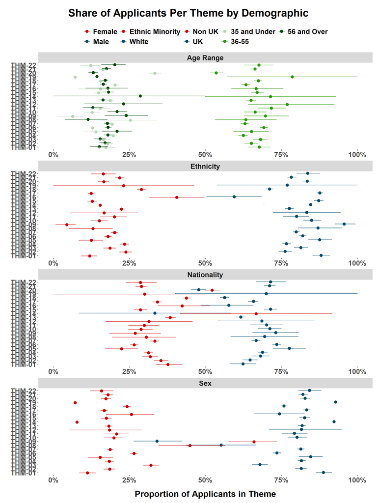

```r
### Applicants
plot_colors <-
  c(
    "Male"= RSSblue,
    "Female"= RSSred,
    "UK"=RSSblue,
    "Non UK"=RSSred,
    "Known Disability"=RSSblue   ,
    "No Known Disability"=RSSred  ,
    "White"=RSSblue  ,
    "Ethnic Minority"=RSSred  ,
    "Unknown"=col_unknown  ,
    "Not Disclosed"=col_notdisclosed  ,
    "35 and Under" = col_age1,
    "36-55" = col_age3,
    "56 and Over" = col_age5,
    "Male.White"=RSSblue,
    "Female.White"=RSSred,
    "Male.Ethnic Minority"=RSSlightblue,
    "Female.Ethnic Minority"=RSSgold,
    "Other"=col_other
  )


t3 <- t3 %>% mutate(
  Group = case_when(
    Group == "EthnicityBinary" ~ "Ethnicity",
    Group == "AgeRangeCollapsed" ~ "Age Range",
    Group == "NationalityBinary" ~ "Nationality",
    TRUE ~ Group
  )
)

# Plot the CIs, faceted by Group, colored by Demographic, with dodged positions
fig19.02 <- ggplot(t3 %>% filter(Group != "Disability"), aes(x = Theme, y = Proportion, color = Demographic)) +
  geom_point(position = position_dodge(width = 0.3), size = 3) +
  geom_errorbar(aes(ymin = CI_L, ymax = CI_U),
                position = position_dodge(width = 0.3),
                width = 0.2) +

  facet_wrap(~ Group, ncol = 1, scales = 'free') +
  scale_color_manual(values = plot_colors) +
  labs(title = "Share of Applicants Per Theme by Demographic",
       x = element_blank(),
       y = "Proportion of Applicants in Theme") +
  scale_y_continuous(limits = c(0,1),
                     labels = scales::percent_format(accuracy = 1)) +

  theme(plot.title = element_text(size = 24, hjust = 0.5, margin = margin(b = 15), face = "bold"),
        plot.title.position = "plot",
        axis.title.x = element_text(size = 20, margin = margin(t = 15), face = "bold"),
        axis.title.y = element_text(size = 20, margin = margin(r = 10), face = "bold"),
        plot.margin = margin(t = 20, r = 10, b = 10, l = 10),
        axis.text.x = element_text(size = 16, face = "bold"),
        axis.text.y = element_text(size = 16, face = "bold"),
        legend.position = "top",
        legend.text = element_text(size = 16, face = "bold"),
        legend.title = element_blank(),
        panel.background = element_rect(fill = "white", color = NA),  # Set panel background to white
        plot.background = element_rect(fill = "white", color = NA),   # Set plot background to white
        #panel.grid.major = element_line(color = "gray90"),            # Optional: adjust grid color
        panel.grid.minor = element_blank(),
        strip.text = element_text(size = 16, face = "bold")
    ) +
  coord_flip()

print(fig19.02)
```

## Awardees

#### Table 19.03 Counts, Proportions, and Confidence Intervals for Demographic Proportions by Research Area, Awardees

```r
## Awardees conf-int Table

df_sex <- Q19RAGAwardees.df %>% filter(Sex != "Unknown" & Sex != "Not Disclosed")
df_ethnicity <- Q19RAGAwardees.df %>% filter(EthnicityBinary != "Unknown" & EthnicityBinary != "Not Disclosed")
df_nationality <- Q19RAGAwardees.df %>% filter(NationalityBinary != "Unknown" & NationalityBinary != "Not Disclosed")
df_disability <- Q19RAGAwardees.df %>% filter(Disability != "Unknown" & Disability != "Not Disclosed")
df_sex_ethnicity <- Q19RAGAwardees.df %>% filter(!str_detect(Sex_Ethnicity, "Unknown|Not Disclosed"))
df_age <- Q19RAGAwardees.df %>% filter(!str_detect(AgeRangeCollapsed, "Unknown|Not Disclosed"), !is.na(AgeRangeCollapsed))




t3 <- compute_statistics(df_sex, "AnonRAG", "Sex")
t3 <- rbind(t3,compute_statistics(df_ethnicity, "AnonRAG", "EthnicityBinary"))
t3 <- rbind(t3,compute_statistics(df_nationality, "AnonRAG", "NationalityBinary"))
t3 <- rbind(t3,compute_statistics(df_disability, "AnonRAG", "Disability"))
t3 <- rbind(t3, compute_statistics(df_age, "AnonRAG", "AgeRangeCollapsed"))

table19.03 <- t3 %>%
  mutate(Count = if_else(Count < 30, "<30", as.character(round(Count / 10) * 10)))

kable(table19.03)
```

| Demographic | Count | Proportion | CI_L | CI_U | Theme | Group |
| --- | --- | --- | --- | --- | --- | --- |
| Female | 590 | 0.1933901 | 0.1796549 | 0.2067980 | RAG-07 | Sex |
| Male | 2460 | 0.8066099 | 0.7925393 | 0.8213351 | RAG-07 | Sex |
| Female | 500 | 0.1720137 | 0.1583704 | 0.1856655 | RAG-09 | Sex |
| Male | 2430 | 0.8279863 | 0.8150171 | 0.8419795 | RAG-09 | Sex |
| Female | 270 | 0.1962209 | 0.1758721 | 0.2151163 | RAG-06 | Sex |
| Male | 1110 | 0.8037791 | 0.7827035 | 0.8263081 | RAG-06 | Sex |
| Female | 580 | 0.1843274 | 0.1710025 | 0.1976523 | RAG-02 | Sex |
| Male | 2570 | 0.8156726 | 0.8026730 | 0.8293147 | RAG-02 | Sex |
| Female | 360 | 0.1894625 | 0.1713677 | 0.2075572 | RAG-08 | Sex |
| Male | 1520 | 0.8105375 | 0.7913784 | 0.8286187 | RAG-08 | Sex |
| Female | 180 | 0.2598870 | 0.2274011 | 0.2923729 | RAG-04 | Sex |
| Male | 520 | 0.7401130 | 0.7062147 | 0.7739754 | RAG-04 | Sex |
| Female | 260 | 0.1859155 | 0.1640845 | 0.2049296 | RAG-05 | Sex |
| Male | 1160 | 0.8140845 | 0.7950704 | 0.8352113 | RAG-05 | Sex |
| Female | 50 | 0.1184834 | 0.0876777 | 0.1492891 | RAG-03 | Sex |
| Male | 370 | 0.8815166 | 0.8507109 | 0.9123223 | RAG-03 | Sex |
| Female | 410 | 0.2546816 | 0.2322256 | 0.2746567 | RAG-01 | Sex |
| Male | 1190 | 0.7453184 | 0.7228464 | 0.7671502 | RAG-01 | Sex |
| Ethnic Minority | 550 | 0.1912073 | 0.1762038 | 0.2055129 | RAG-07 | EthnicityBinary |
| White | 2320 | 0.8087927 | 0.7958828 | 0.8241363 | RAG-07 | EthnicityBinary |
| Ethnic Minority | 300 | 0.1083991 | 0.0965633 | 0.1195262 | RAG-09 | EthnicityBinary |
| White | 2480 | 0.8916009 | 0.8801149 | 0.9030869 | RAG-09 | EthnicityBinary |
| Ethnic Minority | 200 | 0.1557943 | 0.1350729 | 0.1734459 | RAG-06 | EthnicityBinary |
| White | 1100 | 0.8442057 | 0.8242517 | 0.8641596 | RAG-06 | EthnicityBinary |
| Ethnic Minority | 540 | 0.1792736 | 0.1646203 | 0.1929357 | RAG-02 | EthnicityBinary |
| White | 2460 | 0.8207264 | 0.8070643 | 0.8340468 | RAG-02 | EthnicityBinary |
| Ethnic Minority | 340 | 0.1911435 | 0.1737668 | 0.2096413 | RAG-08 | EthnicityBinary |
| White | 1440 | 0.8088565 | 0.7909335 | 0.8267937 | RAG-08 | EthnicityBinary |
| Ethnic Minority | 70 | 0.1008902 | 0.0771890 | 0.1216617 | RAG-04 | EthnicityBinary |
| White | 610 | 0.8991098 | 0.8753709 | 0.9213650 | RAG-04 | EthnicityBinary |

[output cut: 69 more lines]

#### Figure 19.03 Plot of Proportions, and Confidence Intervals for Demographic Proportions by Research Area, Awardees

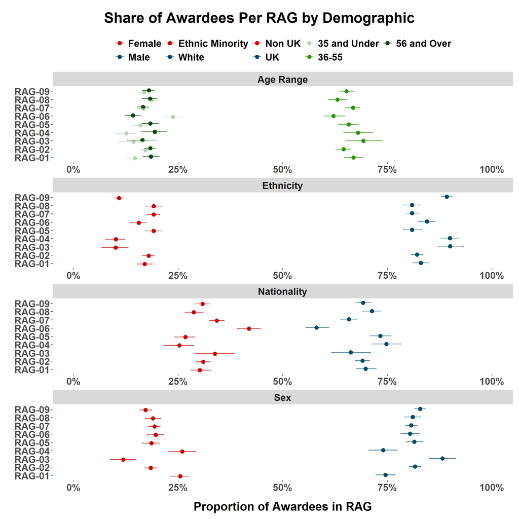

```r
### Awardees
plot_colors <-
  c(
    "Male"= RSSblue,
    "Female"= RSSred,
    "UK"=RSSblue,
    "Non UK"=RSSred,
    "Known Disability"=RSSblue   ,
    "No Known Disability"=RSSred  ,
    "White"=RSSblue  ,
    "Ethnic Minority"=RSSred  ,
    "Unknown"=col_unknown  ,
    "Not Disclosed"=col_notdisclosed  ,
    "35 and Under" = col_age1,
    "36-55" = col_age3,
    "56 and Over" = col_age5,
    "Male.White"=RSSblue,
    "Female.White"=RSSred,
    "Male.Ethnic Minority"=RSSlightblue,
    "Female.Ethnic Minority"=RSSgold,
    "Other"=col_other
  )


t3 <- t3 %>% mutate(
  Group = case_when(
    Group == "EthnicityBinary" ~ "Ethnicity",
    Group == "AgeRangeCollapsed" ~ "Age Range",
    Group == "NationalityBinary" ~ "Nationality",
    TRUE ~ Group
  )
)

# Plot the CIs, faceted by Group, colored by Demographic, with dodged positions
fig19.03 <- ggplot(t3 %>% filter(Group != "Disability"), aes(x = Theme, y = Proportion, color = Demographic)) +
  geom_point(position = position_dodge(width = 0.3), size = 3) +
  geom_errorbar(aes(ymin = CI_L, ymax = CI_U),
                position = position_dodge(width = 0.3),
                width = 0.2) +

  facet_wrap(~ Group, ncol = 1, scales = 'free') +
  scale_color_manual(values = plot_colors) +
  labs(title = "Share of Awardees Per RAG by Demographic",
       x = element_blank(),
       y = "Proportion of Awardees in RAG") +
  scale_y_continuous(limits = c(0,1),
                     labels = scales::percent_format(accuracy = 1)) +

  theme(plot.title = element_text(size = 24, hjust = 0.5, margin = margin(b = 15), face = "bold"),
        plot.title.position = "plot",
        axis.title.x = element_text(size = 20, margin = margin(t = 15), face = "bold"),
        axis.title.y = element_text(size = 20, margin = margin(r = 10), face = "bold"),
        plot.margin = margin(t = 20, r = 10, b = 10, l = 10),
        axis.text.x = element_text(size = 16, face = "bold"),
        axis.text.y = element_text(size = 16, face = "bold"),
        legend.position = "top",
        legend.text = element_text(size = 16, face = "bold"),
        legend.title = element_blank(),
        panel.background = element_rect(fill = "white", color = NA),  # Set panel background to white
        plot.background = element_rect(fill = "white", color = NA),   # Set plot background to white
        #panel.grid.major = element_line(color = "gray90"),            # Optional: adjust grid color
        panel.grid.minor = element_blank(),
        strip.text = element_text(size = 16, face = "bold")
    ) +
  coord_flip()

print(fig19.03)
```

#### Table 19.04 Counts, Proportions, and Confidence Intervals for Demographic Proportions by Theme, Awardees

```r
## Awardees conf-int Table

df_sex <- Q19thmAwardees.df %>% filter(Sex != "Unknown" & Sex != "Not Disclosed")
df_ethnicity <- Q19thmAwardees.df %>% filter(EthnicityBinary != "Unknown" & EthnicityBinary != "Not Disclosed")
df_nationality <- Q19thmAwardees.df %>% filter(NationalityBinary != "Unknown" & NationalityBinary != "Not Disclosed")
df_disability <- Q19thmAwardees.df %>% filter(Disability != "Unknown" & Disability != "Not Disclosed")
df_sex_ethnicity <- Q19thmAwardees.df %>% filter(!str_detect(Sex_Ethnicity, "Unknown|Not Disclosed"))
df_age <- Q19thmAwardees.df %>% filter(!str_detect(AgeRangeCollapsed, "Unknown|Not Disclosed"), !is.na(AgeRangeCollapsed))




t3 <- compute_statistics(df_sex, "AnonTHM", "Sex")
t3 <- rbind(t3,compute_statistics(df_ethnicity, "AnonTHM", "EthnicityBinary"))
```

```
## [1] "All values of t are equal to  1 \n Cannot calculate confidence intervals"
```

```r
t3 <- rbind(t3,compute_statistics(df_nationality, "AnonTHM", "NationalityBinary"))
t3 <- rbind(t3,compute_statistics(df_disability, "AnonTHM", "Disability"))
```

```
## [1] "All values of t are equal to  1 \n Cannot calculate confidence intervals"
## [1] "All values of t are equal to  1 \n Cannot calculate confidence intervals"
## [1] "All values of t are equal to  1 \n Cannot calculate confidence intervals"
```

```r
t3 <- rbind(t3, compute_statistics(df_age, "AnonTHM", "AgeRangeCollapsed"))
```

```
## [1] "All values of t are equal to  1 \n Cannot calculate confidence intervals"
```

```r
table19.04 <- t3 %>%
  mutate(Count = if_else(Count < 30, "<30", as.character(round(Count / 10) * 10)))

kable(table19.04)
```

| Demographic | Count | Proportion | CI_L | CI_U | Theme | Group |
| --- | --- | --- | --- | --- | --- | --- |
| Female | 210 | 0.1359846 | 0.1173992 | 0.1513791 | THM-13 | Sex |
| Male | 1350 | 0.8640154 | 0.8467129 | 0.8819756 | THM-13 | Sex |
| Female | 290 | 0.1483771 | 0.1319039 | 0.1638331 | THM-17 | Sex |
| Male | 1650 | 0.8516229 | 0.8361669 | 0.8670788 | THM-17 | Sex |
| Female | 480 | 0.2255924 | 0.2071090 | 0.2421801 | THM-18 | Sex |
| Male | 1630 | 0.7744076 | 0.7563981 | 0.7919431 | THM-18 | Sex |
| Female | 170 | 0.1890661 | 0.1628702 | 0.2141230 | THM-20 | Sex |
| Male | 710 | 0.8109339 | 0.7847380 | 0.8371298 | THM-20 | Sex |
| Female | 330 | 0.1690722 | 0.1525773 | 0.1850515 | THM-07 | Sex |
| Male | 1610 | 0.8309278 | 0.8144330 | 0.8474096 | THM-07 | Sex |
| Female | 300 | 0.1856360 | 0.1643490 | 0.2026626 | THM-04 | Sex |
| Male | 1340 | 0.8143640 | 0.7948874 | 0.8326233 | THM-04 | Sex |
| Female | 40 | 0.1455939 | 0.1034483 | 0.1877395 | THM-05 | Sex |
| Male | 220 | 0.8544061 | 0.8160920 | 0.8965517 | THM-05 | Sex |
| Female | <30 | 0.1161290 | 0.0645161 | 0.1677419 | THM-22 | Sex |
| Male | 140 | 0.8838710 | 0.8322581 | 0.9354839 | THM-22 | Sex |
| Female | 410 | 0.2560899 | 0.2348532 | 0.2767021 | THM-06 | Sex |
| Male | 1190 | 0.7439101 | 0.7208154 | 0.7651468 | THM-06 | Sex |
| Female | <30 | 0.1608392 | 0.0979021 | 0.2167832 | THM-11 | Sex |
| Male | 120 | 0.8391608 | 0.7832168 | 0.9090909 | THM-11 | Sex |
| Female | 220 | 0.1846661 | 0.1632317 | 0.2061006 | THM-15 | Sex |
| Male | 990 | 0.8153339 | 0.7947238 | 0.8367683 | THM-15 | Sex |
| Female | 210 | 0.1635220 | 0.1430818 | 0.1839623 | THM-21 | Sex |
| Male | 1060 | 0.8364780 | 0.8176300 | 0.8577044 | THM-21 | Sex |
| Female | 40 | 0.1005435 | 0.0679348 | 0.1331522 | THM-01 | Sex |
| Male | 330 | 0.8994565 | 0.8695652 | 0.9320652 | THM-01 | Sex |
| Female | 180 | 0.3410405 | 0.2987002 | 0.3814539 | THM-03 | Sex |
| Male | 340 | 0.6589595 | 0.6204239 | 0.6994220 | THM-03 | Sex |
| Female | 80 | 0.1950617 | 0.1555556 | 0.2320988 | THM-10 | Sex |
| Male | 330 | 0.8049383 | 0.7630257 | 0.8444444 | THM-10 | Sex |

[output cut: 182 more lines]

#### Figure 19.04 Plot of Proportions, and Confidence Intervals for Demographic Proportions by Theme, Awardees

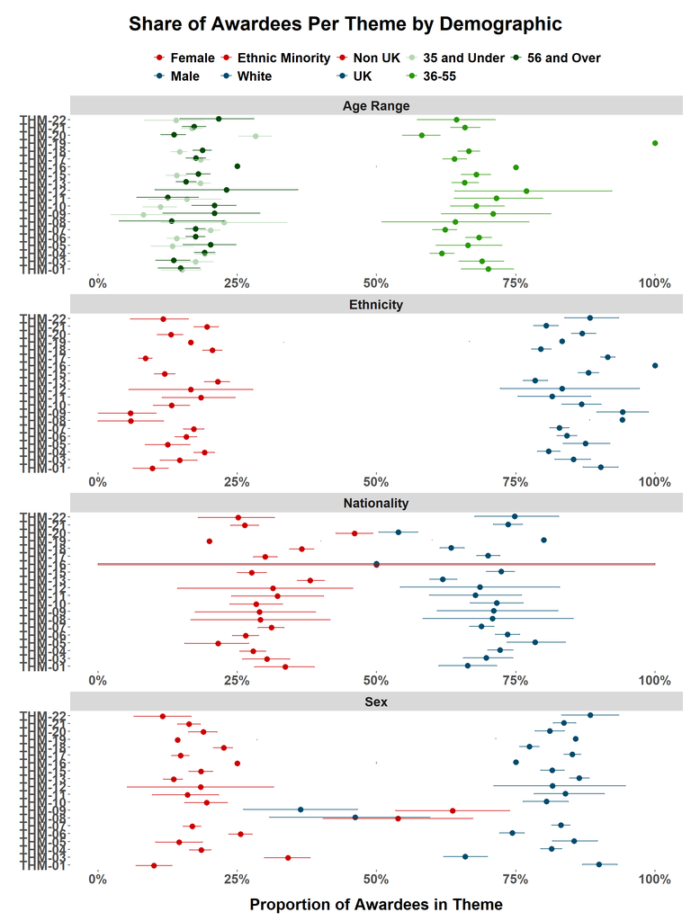

```r
### Awardees
plot_colors <-
  c(
    "Male"= RSSblue,
    "Female"= RSSred,
    "UK"=RSSblue,
    "Non UK"=RSSred,
    "Known Disability"=RSSblue   ,
    "No Known Disability"=RSSred  ,
    "White"=RSSblue  ,
    "Ethnic Minority"=RSSred  ,
    "Unknown"=col_unknown  ,
    "Not Disclosed"=col_notdisclosed  ,
    "35 and Under" = col_age1,
    "36-55" = col_age3,
    "56 and Over" = col_age5,
    "Male.White"=RSSblue,
    "Female.White"=RSSred,
    "Male.Ethnic Minority"=RSSlightblue,
    "Female.Ethnic Minority"=RSSgold,
    "Other"=col_other
  )


t3 <- t3 %>% mutate(
  Group = case_when(
    Group == "EthnicityBinary" ~ "Ethnicity",
    Group == "AgeRangeCollapsed" ~ "Age Range",
    Group == "NationalityBinary" ~ "Nationality",
    TRUE ~ Group
  )
)

# Plot the CIs, faceted by Group, colored by Demographic, with dodged positions
fig19.04 <- ggplot(t3 %>% filter(Group != "Disability"), aes(x = Theme, y = Proportion, color = Demographic)) +
  geom_point(position = position_dodge(width = 0.3), size = 3) +
  geom_errorbar(aes(ymin = CI_L, ymax = CI_U),
                position = position_dodge(width = 0.3),
                width = 0.2) +

  facet_wrap(~ Group, ncol = 1, scales = 'free') +
  scale_color_manual(values = plot_colors) +
  labs(title = "Share of Awardees Per Theme by Demographic",
       x = element_blank(),
       y = "Proportion of Awardees in Theme") +
  scale_y_continuous(limits = c(0,1),
                     labels = scales::percent_format(accuracy = 1)) +

  theme(plot.title = element_text(size = 24, hjust = 0.5, margin = margin(b = 15), face = "bold"),
        plot.title.position = "plot",
        axis.title.x = element_text(size = 20, margin = margin(t = 15), face = "bold"),
        axis.title.y = element_text(size = 20, margin = margin(r = 10), face = "bold"),
        plot.margin = margin(t = 20, r = 10, b = 10, l = 10),
        axis.text.x = element_text(size = 16, face = "bold"),
        axis.text.y = element_text(size = 16, face = "bold"),
        legend.position = "top",
        legend.text = element_text(size = 16, face = "bold"),
        legend.title = element_blank(),
        panel.background = element_rect(fill = "white", color = NA),  # Set panel background to white
        plot.background = element_rect(fill = "white", color = NA),   # Set plot background to white
        #panel.grid.major = element_line(color = "gray90"),            # Optional: adjust grid color
        panel.grid.minor = element_blank(),
        strip.text = element_text(size = 16, face = "bold")
    ) +
  coord_flip()

print(fig19.04)
```

## Reviewers

#### Table 19.05 Counts, Proportions, and Confidence Intervals for Demographic Proportions by Research Area, Reviewers

```r
## Reviewers conf-int Table

df_sex <- Q19RAGReviewers.df %>% filter(Sex != "Unknown" & Sex != "Not Disclosed")
df_ethnicity <- Q19RAGReviewers.df %>% filter(EthnicityBinary != "Unknown" & EthnicityBinary != "Not Disclosed")
df_nationality <- Q19RAGReviewers.df %>% filter(NationalityBinary != "Unknown" & NationalityBinary != "Not Disclosed")
df_disability <- Q19RAGReviewers.df %>% filter(Disability != "Unknown" & Disability != "Not Disclosed")
df_sex_ethnicity <- Q19RAGReviewers.df %>% filter(!str_detect(Sex_Ethnicity, "Unknown|Not Disclosed"))
df_age <- Q19RAGReviewers.df %>% filter(!str_detect(AgeRangeCollapsed, "Unknown|Not Disclosed"), !is.na(AgeRangeCollapsed))



t3 <- compute_statistics(df_sex, "AnonRAG", "Sex")
t3 <- rbind(t3,compute_statistics(df_ethnicity, "AnonRAG", "EthnicityBinary"))
t3 <- rbind(t3,compute_statistics(df_nationality, "AnonRAG", "NationalityBinary"))
t3 <- rbind(t3,compute_statistics(df_disability, "AnonRAG", "Disability"))
t3 <- rbind(t3, compute_statistics(df_age, "AnonRAG", "AgeRangeCollapsed"))

table19.05 <- t3 %>%
  mutate(Count = if_else(Count < 30, "<30", as.character(round(Count / 10) * 10)))

kable(table19.05)
```

| Demographic | Count | Proportion | CI_L | CI_U | Theme | Group |
| --- | --- | --- | --- | --- | --- | --- |
| Female | 750 | 0.1483244 | 0.1392029 | 0.1582341 | RAG-09 | Sex |
| Male | 4300 | 0.8516756 | 0.8411660 | 0.8617886 | RAG-09 | Sex |
| Female | 850 | 0.1726517 | 0.1627156 | 0.1829986 | RAG-07 | Sex |
| Male | 4080 | 0.8273483 | 0.8163979 | 0.8374924 | RAG-07 | Sex |
| Female | 720 | 0.1408948 | 0.1312894 | 0.1507015 | RAG-02 | Sex |
| Male | 4380 | 0.8591052 | 0.8494898 | 0.8683231 | RAG-02 | Sex |
| Female | 410 | 0.1336570 | 0.1223301 | 0.1459547 | RAG-06 | Sex |
| Male | 2680 | 0.8663430 | 0.8527590 | 0.8783172 | RAG-06 | Sex |
| Female | 270 | 0.1368209 | 0.1222334 | 0.1509054 | RAG-05 | Sex |
| Male | 1720 | 0.8631791 | 0.8480885 | 0.8787726 | RAG-05 | Sex |
| Female | 580 | 0.2103725 | 0.1953981 | 0.2257122 | RAG-01 | Sex |
| Male | 2160 | 0.7896275 | 0.7742878 | 0.8060628 | RAG-01 | Sex |
| Female | 310 | 0.1296219 | 0.1159119 | 0.1429165 | RAG-08 | Sex |
| Male | 2100 | 0.8703781 | 0.8574990 | 0.8840881 | RAG-08 | Sex |
| Female | 130 | 0.1695828 | 0.1426649 | 0.1965007 | RAG-04 | Sex |
| Male | 620 | 0.8304172 | 0.8034993 | 0.8573009 | RAG-04 | Sex |
| Female | 40 | 0.0899358 | 0.0642398 | 0.1155773 | RAG-03 | Sex |
| Male | 420 | 0.9100642 | 0.8843683 | 0.9357602 | RAG-03 | Sex |
| Ethnic Minority | 650 | 0.1396839 | 0.1304998 | 0.1495088 | RAG-09 | EthnicityBinary |
| White | 4030 | 0.8603161 | 0.8502831 | 0.8699220 | RAG-09 | EthnicityBinary |
| Ethnic Minority | 920 | 0.2025652 | 0.1915082 | 0.2149491 | RAG-07 | EthnicityBinary |
| White | 3610 | 0.7974348 | 0.7852776 | 0.8091496 | RAG-07 | EthnicityBinary |
| Ethnic Minority | 1050 | 0.2192525 | 0.2079766 | 0.2313635 | RAG-02 | EthnicityBinary |
| White | 3740 | 0.7807475 | 0.7692682 | 0.7920181 | RAG-02 | EthnicityBinary |
| Ethnic Minority | 420 | 0.1511965 | 0.1374184 | 0.1653280 | RAG-06 | EthnicityBinary |
| White | 2340 | 0.8488035 | 0.8357505 | 0.8622098 | RAG-06 | EthnicityBinary |
| Ethnic Minority | 430 | 0.2292553 | 0.2101064 | 0.2473404 | RAG-05 | EthnicityBinary |
| White | 1450 | 0.7707447 | 0.7515957 | 0.7893617 | RAG-05 | EthnicityBinary |
| Ethnic Minority | 510 | 0.1982052 | 0.1825985 | 0.2138119 | RAG-01 | EthnicityBinary |
| White | 2060 | 0.8017948 | 0.7865782 | 0.8197425 | RAG-01 | EthnicityBinary |

[output cut: 69 more lines]

#### Figure 19.05 Plot of Proportions, and Confidence Intervals for Demographic Proportions by Research Area, Reviewers

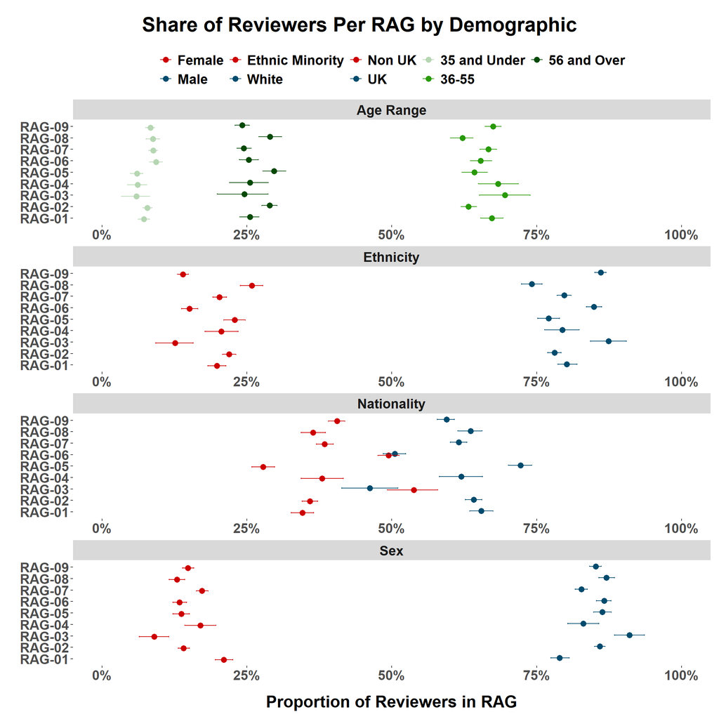

```r
### Reviewers
plot_colors <-
  c(
    "Male"= RSSblue,
    "Female"= RSSred,
    "UK"=RSSblue,
    "Non UK"=RSSred,
    "Known Disability"=RSSblue   ,
    "No Known Disability"=RSSred  ,
    "White"=RSSblue  ,
    "Ethnic Minority"=RSSred  ,
    "Unknown"=col_unknown  ,
    "Not Disclosed"=col_notdisclosed  ,
    "35 and Under" = col_age1,
    "36-55" = col_age3,
    "56 and Over" = col_age5,
    "Male.White"=RSSblue,
    "Female.White"=RSSred,
    "Male.Ethnic Minority"=RSSlightblue,
    "Female.Ethnic Minority"=RSSgold,
    "Other"=col_other
  )


t3 <- t3 %>% mutate(
  Group = case_when(
    Group == "EthnicityBinary" ~ "Ethnicity",
    Group == "AgeRangeCollapsed" ~ "Age Range",
    Group == "NationalityBinary" ~ "Nationality",
    TRUE ~ Group
  )
)

# Plot the CIs, faceted by Group, colored by Demographic, with dodged positions
fig19.05 <- ggplot(t3 %>% filter(Group != "Disability"), aes(x = Theme, y = Proportion, color = Demographic)) +
  geom_point(position = position_dodge(width = 0.3), size = 3) +
  geom_errorbar(aes(ymin = CI_L, ymax = CI_U),
                position = position_dodge(width = 0.3),
                width = 0.2) +

  facet_wrap(~ Group, ncol = 1, scales = 'free') +
  scale_color_manual(values = plot_colors) +
  labs(title = "Share of Reviewers Per RAG by Demographic",
       x = element_blank(),
       y = "Proportion of Reviewers in RAG") +
  scale_y_continuous(limits = c(0,1),
                     labels = scales::percent_format(accuracy = 1)) +

  theme(plot.title = element_text(size = 24, hjust = 0.5, margin = margin(b = 15), face = "bold"),
        plot.title.position = "plot",
        axis.title.x = element_text(size = 20, margin = margin(t = 15), face = "bold"),
        axis.title.y = element_text(size = 20, margin = margin(r = 10), face = "bold"),
        plot.margin = margin(t = 20, r = 10, b = 10, l = 10),
        axis.text.x = element_text(size = 16, face = "bold"),
        axis.text.y = element_text(size = 16, face = "bold"),
        legend.position = "top",
        legend.text = element_text(size = 16, face = "bold"),
        legend.title = element_blank(),
        panel.background = element_rect(fill = "white", color = NA),  # Set panel background to white
        plot.background = element_rect(fill = "white", color = NA),   # Set plot background to white
        #panel.grid.major = element_line(color = "gray90"),            # Optional: adjust grid color
        panel.grid.minor = element_blank(),
        strip.text = element_text(size = 16, face = "bold")
    ) +
  coord_flip()

print(fig19.05)
```

```r
## Reviewers conf-int Table

df_sex <- Q19thmAwardees.df %>% filter(Sex != "Unknown" & Sex != "Not Disclosed")
df_ethnicity <- Q19thmAwardees.df %>% filter(EthnicityBinary != "Unknown" & EthnicityBinary != "Not Disclosed")
df_nationality <- Q19thmAwardees.df %>% filter(NationalityBinary != "Unknown" & NationalityBinary != "Not Disclosed")
df_disability <- Q19thmAwardees.df %>% filter(Disability != "Unknown" & Disability != "Not Disclosed")
df_sex_ethnicity <- Q19thmAwardees.df %>% filter(!str_detect(Sex_Ethnicity, "Unknown|Not Disclosed"))
df_age <- Q19thmAwardees.df %>% filter(!str_detect(AgeRangeCollapsed, "Unknown|Not Disclosed"), !is.na(AgeRangeCollapsed))



t3 <- compute_statistics(df_sex, "AnonTHM", "Sex")
t3 <- rbind(t3,compute_statistics(df_ethnicity, "AnonTHM", "EthnicityBinary"))
```

```
## [1] "All values of t are equal to  1 \n Cannot calculate confidence intervals"
```

```r
t3 <- rbind(t3,compute_statistics(df_nationality, "AnonTHM", "NationalityBinary"))
t3 <- rbind(t3,compute_statistics(df_disability, "AnonTHM", "Disability"))
```

```
## [1] "All values of t are equal to  1 \n Cannot calculate confidence intervals"
## [1] "All values of t are equal to  1 \n Cannot calculate confidence intervals"
## [1] "All values of t are equal to  1 \n Cannot calculate confidence intervals"
```

```r
t3 <- rbind(t3, compute_statistics(df_age, "AnonTHM", "AgeRangeCollapsed"))
```

```
## [1] "All values of t are equal to  1 \n Cannot calculate confidence intervals"
```

```r
table19.06 <- t3 %>%
  mutate(Count = if_else(Count < 30, "<30", as.character(round(Count / 10) * 10)))

kable(table19.06)
```

| Demographic | Count | Proportion | CI_L | CI_U | Theme | Group |
| --- | --- | --- | --- | --- | --- | --- |
| Female | 210 | 0.1359846 | 0.1186821 | 0.1526620 | THM-13 | Sex |
| Male | 1350 | 0.8640154 | 0.8447886 | 0.8813342 | THM-13 | Sex |
| Female | 290 | 0.1483771 | 0.1324060 | 0.1633179 | THM-17 | Sex |
| Male | 1650 | 0.8516229 | 0.8346213 | 0.8675809 | THM-17 | Sex |
| Female | 480 | 0.2255924 | 0.2085308 | 0.2426540 | THM-18 | Sex |
| Male | 1630 | 0.7744076 | 0.7568841 | 0.7924050 | THM-18 | Sex |
| Female | 170 | 0.1890661 | 0.1617312 | 0.2141230 | THM-20 | Sex |
| Male | 710 | 0.8109339 | 0.7835991 | 0.8371298 | THM-20 | Sex |
| Female | 330 | 0.1690722 | 0.1520619 | 0.1865979 | THM-07 | Sex |
| Male | 1610 | 0.8309278 | 0.8149485 | 0.8474227 | THM-07 | Sex |
| Female | 300 | 0.1856360 | 0.1655508 | 0.2044885 | THM-04 | Sex |
| Male | 1340 | 0.8143640 | 0.7954960 | 0.8338251 | THM-04 | Sex |
| Female | 40 | 0.1455939 | 0.0996169 | 0.1839080 | THM-05 | Sex |
| Male | 220 | 0.8544061 | 0.8160920 | 0.9002858 | THM-05 | Sex |
| Female | <30 | 0.1161290 | 0.0645161 | 0.1612903 | THM-22 | Sex |
| Male | 140 | 0.8838710 | 0.8387097 | 0.9354839 | THM-22 | Sex |
| Female | 410 | 0.2560899 | 0.2336040 | 0.2779354 | THM-06 | Sex |
| Male | 1190 | 0.7439101 | 0.7220487 | 0.7663960 | THM-06 | Sex |
| Female | <30 | 0.1608392 | 0.0979021 | 0.2167832 | THM-11 | Sex |
| Male | 120 | 0.8391608 | 0.7832168 | 0.9020979 | THM-11 | Sex |
| Female | 220 | 0.1846661 | 0.1624073 | 0.2061006 | THM-15 | Sex |
| Male | 990 | 0.8153339 | 0.7947238 | 0.8359439 | THM-15 | Sex |
| Female | 210 | 0.1635220 | 0.1415094 | 0.1839623 | THM-21 | Sex |
| Male | 1060 | 0.8364780 | 0.8152516 | 0.8553459 | THM-21 | Sex |
| Female | 40 | 0.1005435 | 0.0679348 | 0.1277174 | THM-01 | Sex |
| Male | 330 | 0.8994565 | 0.8695652 | 0.9320652 | THM-01 | Sex |
| Female | 180 | 0.3410405 | 0.3005780 | 0.3834297 | THM-03 | Sex |
| Male | 340 | 0.6589595 | 0.6166193 | 0.7013487 | THM-03 | Sex |
| Female | 80 | 0.1950617 | 0.1531491 | 0.2345679 | THM-10 | Sex |
| Male | 330 | 0.8049383 | 0.7654948 | 0.8444444 | THM-10 | Sex |

[output cut: 182 more lines]

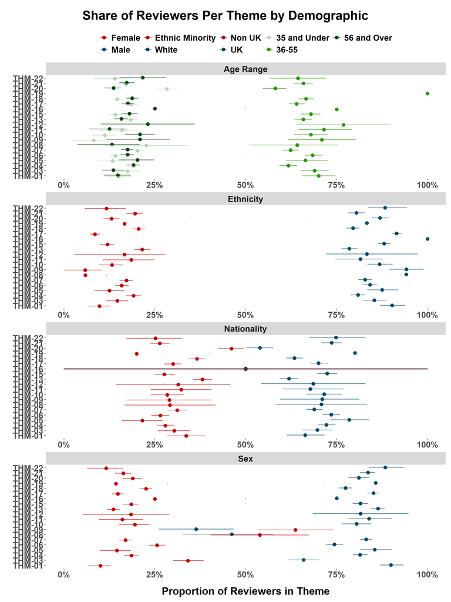

```r
### Reviewers
plot_colors <-
  c(
    "Male"= RSSblue,
    "Female"= RSSred,
    "UK"=RSSblue,
    "Non UK"=RSSred,
    "Known Disability"=RSSblue   ,
    "No Known Disability"=RSSred  ,
    "White"=RSSblue  ,
    "Ethnic Minority"=RSSred  ,
    "Unknown"=col_unknown  ,
    "Not Disclosed"=col_notdisclosed  ,
    "35 and Under" = col_age1,
    "36-55" = col_age3,
    "56 and Over" = col_age5,
    "Male.White"=RSSblue,
    "Female.White"=RSSred,
    "Male.Ethnic Minority"=RSSlightblue,
    "Female.Ethnic Minority"=RSSgold,
    "Other"=col_other
  )


t3 <- t3 %>% mutate(
  Group = case_when(
    Group == "EthnicityBinary" ~ "Ethnicity",
    Group == "AgeRangeCollapsed" ~ "Age Range",
    Group == "NationalityBinary" ~ "Nationality",
    TRUE ~ Group
  )
)

# Plot the CIs, faceted by Group, colored by Demographic, with dodged positions
fig19.06 <- ggplot(t3 %>% filter(Group != "Disability"), aes(x = Theme, y = Proportion, color = Demographic)) +
  geom_point(position = position_dodge(width = 0.3), size = 3) +
  geom_errorbar(aes(ymin = CI_L, ymax = CI_U),
                position = position_dodge(width = 0.3),
                width = 0.2) +

  facet_wrap(~ Group, ncol = 1, scales = 'free') +
  scale_color_manual(values = plot_colors) +
  labs(title = "Share of Reviewers Per Theme by Demographic",
       x = element_blank(),
       y = "Proportion of Reviewers in Theme") +
  scale_y_continuous(limits = c(0,1),
                     labels = scales::percent_format(accuracy = 1)) +

  theme(plot.title = element_text(size = 24, hjust = 0.5, margin = margin(b = 15), face = "bold"),
        plot.title.position = "plot",
        axis.title.x = element_text(size = 20, margin = margin(t = 15), face = "bold"),
        axis.title.y = element_text(size = 20, margin = margin(r = 10), face = "bold"),
        plot.margin = margin(t = 20, r = 10, b = 10, l = 10),
        axis.text.x = element_text(size = 16, face = "bold"),
        axis.text.y = element_text(size = 16, face = "bold"),
        legend.position = "top",
        legend.text = element_text(size = 16, face = "bold"),
        legend.title = element_blank(),
        panel.background = element_rect(fill = "white", color = NA),  # Set panel background to white
        plot.background = element_rect(fill = "white", color = NA),   # Set plot background to white
        #panel.grid.major = element_line(color = "gray90"),            # Optional: adjust grid color
        panel.grid.minor = element_blank(),
        strip.text = element_text(size = 16, face = "bold")
    ) +
  coord_flip()

print(fig19.06)
```

## Panelists

#### Table 19.07 Counts, Proportions, and Confidence Intervals for Demographic Proportions by Research Area, Panelists

```r
## Panelists conf-int Table

df_sex <- Q19RAGPanelists.df %>% filter(Sex != "Unknown" & Sex != "Not Disclosed")
df_ethnicity <- Q19RAGPanelists.df %>% filter(EthnicityBinary != "Unknown" & EthnicityBinary != "Not Disclosed")
df_nationality <- Q19RAGPanelists.df %>% filter(NationalityBinary != "Unknown" & NationalityBinary != "Not Disclosed")
df_disability <- Q19RAGPanelists.df %>% filter(Disability != "Unknown" & Disability != "Not Disclosed")
df_sex_ethnicity <- Q19RAGPanelists.df %>% filter(!str_detect(Sex_Ethnicity, "Unknown|Not Disclosed"))
df_age <- Q19RAGPanelists.df %>% filter(!str_detect(AgeRangeCollapsed, "Unknown|Not Disclosed"), !is.na(AgeRangeCollapsed))



t3 <- compute_statistics(df_sex, "AnonRAG", "Sex")
t3 <- rbind(t3,compute_statistics(df_ethnicity, "AnonRAG", "EthnicityBinary"))
t3 <- rbind(t3,compute_statistics(df_nationality, "AnonRAG", "NationalityBinary"))
t3 <- rbind(t3,compute_statistics(df_disability, "AnonRAG", "Disability"))
t3 <- rbind(t3, compute_statistics(df_age, "AnonRAG", "AgeRangeCollapsed"))

table19.07 <- t3 %>%
  mutate(Count = if_else(Count < 30, "<30", as.character(round(Count / 10) * 10)))

kable(table19.07)
```

| Demographic | Count | Proportion | CI_L | CI_U | Theme | Group |
| --- | --- | --- | --- | --- | --- | --- |
| Female | 540 | 0.2655172 | 0.2458128 | 0.2847291 | RAG-09 | Sex |
| Male | 1490 | 0.7344828 | 0.7138056 | 0.7536946 | RAG-09 | Sex |
| Female | 590 | 0.2774621 | 0.2575878 | 0.2954545 | RAG-07 | Sex |
| Male | 1530 | 0.7225379 | 0.7035985 | 0.7428977 | RAG-07 | Sex |
| Female | 610 | 0.2827201 | 0.2636237 | 0.3022823 | RAG-02 | Sex |
| Male | 1540 | 0.7172799 | 0.6986493 | 0.7349672 | RAG-02 | Sex |
| Female | 440 | 0.2956698 | 0.2719892 | 0.3186739 | RAG-06 | Sex |
| Male | 1040 | 0.7043302 | 0.6799901 | 0.7279936 | RAG-06 | Sex |
| Female | 450 | 0.2871861 | 0.2633776 | 0.3110109 | RAG-01 | Sex |
| Male | 1110 | 0.7128139 | 0.6896493 | 0.7366224 | RAG-01 | Sex |
| Female | 440 | 0.2840542 | 0.2601679 | 0.3072786 | RAG-08 | Sex |
| Male | 1110 | 0.7159458 | 0.6920758 | 0.7378954 | RAG-08 | Sex |
| Female | 210 | 0.3296178 | 0.2929936 | 0.3662016 | RAG-04 | Sex |
| Male | 420 | 0.6703822 | 0.6321656 | 0.7054140 | RAG-04 | Sex |
| Female | 340 | 0.2846284 | 0.2593120 | 0.3099448 | RAG-05 | Sex |
| Male | 850 | 0.7153716 | 0.6908784 | 0.7415326 | RAG-05 | Sex |
| Female | 170 | 0.3029197 | 0.2627737 | 0.3448905 | RAG-03 | Sex |
| Male | 380 | 0.6970803 | 0.6588055 | 0.7372263 | RAG-03 | Sex |
| Ethnic Minority | 220 | 0.1181144 | 0.1022246 | 0.1308263 | RAG-09 | EthnicityBinary |
| White | 1660 | 0.8818856 | 0.8670551 | 0.8961864 | RAG-09 | EthnicityBinary |
| Ethnic Minority | 260 | 0.1362924 | 0.1206399 | 0.1514228 | RAG-07 | EthnicityBinary |
| White | 1650 | 0.8637076 | 0.8485640 | 0.8793734 | RAG-07 | EthnicityBinary |
| Ethnic Minority | 260 | 0.1307457 | 0.1159346 | 0.1455437 | RAG-02 | EthnicityBinary |
| White | 1700 | 0.8692543 | 0.8539456 | 0.8840654 | RAG-02 | EthnicityBinary |
| Ethnic Minority | 170 | 0.1249076 | 0.1071880 | 0.1419069 | RAG-06 | EthnicityBinary |
| White | 1180 | 0.8750924 | 0.8588322 | 0.8928307 | RAG-06 | EthnicityBinary |
| Ethnic Minority | 190 | 0.1313412 | 0.1139680 | 0.1487144 | RAG-01 | EthnicityBinary |
| White | 1250 | 0.8686588 | 0.8519805 | 0.8867269 | RAG-01 | EthnicityBinary |
| Ethnic Minority | 180 | 0.1293043 | 0.1131413 | 0.1454673 | RAG-08 | EthnicityBinary |
| White | 1240 | 0.8706957 | 0.8538478 | 0.8889670 | RAG-08 | EthnicityBinary |

[output cut: 69 more lines]

#### Figure 19.07 Plot of Proportions, and Confidence Intervals for Demographic Proportions by Research Area, Panelists

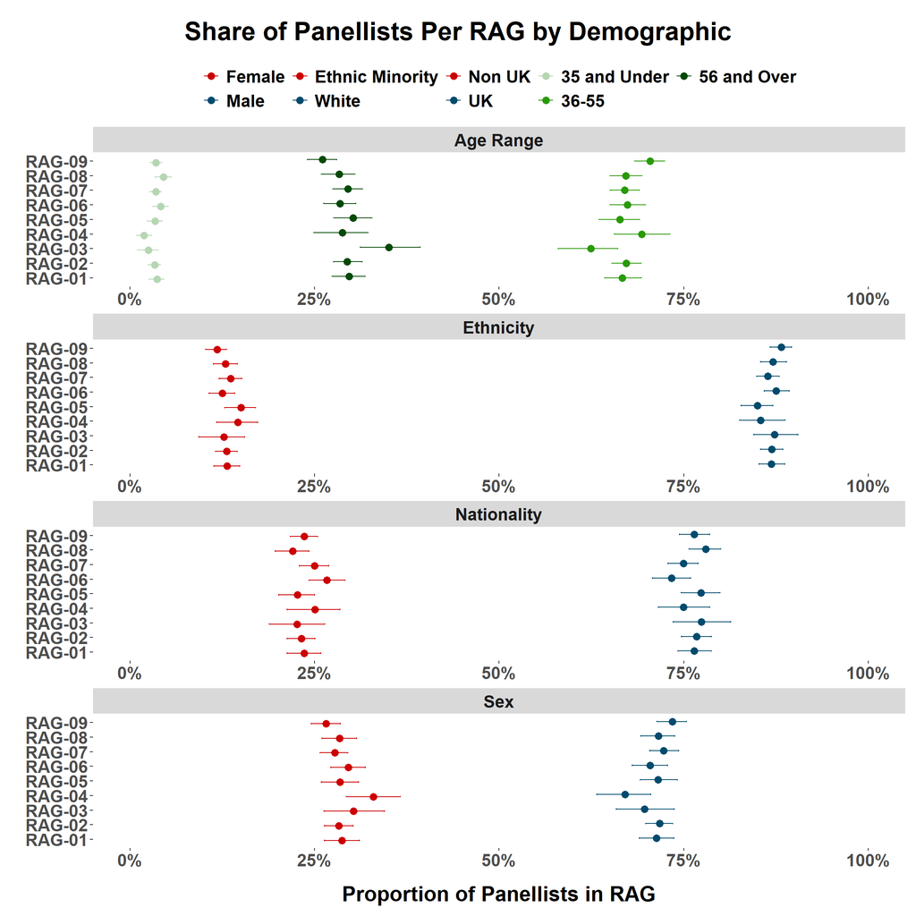

```r
### Panelists
plot_colors <-
  c(
    "Male"= RSSblue,
    "Female"= RSSred,
    "UK"=RSSblue,
    "Non UK"=RSSred,
    "Known Disability"=RSSblue   ,
    "No Known Disability"=RSSred  ,
    "White"=RSSblue  ,
    "Ethnic Minority"=RSSred  ,
    "Unknown"=col_unknown  ,
    "Not Disclosed"=col_notdisclosed  ,
    "35 and Under" = col_age1,
    "36-55" = col_age3,
    "56 and Over" = col_age5,
    "Male.White"=RSSblue,
    "Female.White"=RSSred,
    "Male.Ethnic Minority"=RSSlightblue,
    "Female.Ethnic Minority"=RSSgold,
    "Other"=col_other
  )


t3 <- t3 %>% mutate(
  Group = case_when(
    Group == "EthnicityBinary" ~ "Ethnicity",
    Group == "AgeRangeCollapsed" ~ "Age Range",
    Group == "NationalityBinary" ~ "Nationality",
    TRUE ~ Group
  )
)

# Plot the CIs, faceted by Group, colored by Demographic, with dodged positions
fig19.07 <- ggplot(t3 %>% filter(Group != "Disability"), aes(x = Theme, y = Proportion, color = Demographic)) +
  geom_point(position = position_dodge(width = 0.3), size = 3) +
  geom_errorbar(aes(ymin = CI_L, ymax = CI_U),
                position = position_dodge(width = 0.3),
                width = 0.2) +

  facet_wrap(~ Group, ncol = 1, scales = 'free') +
  scale_color_manual(values = plot_colors) +
  labs(title = "Share of Panellists Per RAG by Demographic",
       x = element_blank(),
       y = "Proportion of Panellists in RAG") +
  scale_y_continuous(limits = c(0,1),
                     labels = scales::percent_format(accuracy = 1)) +

  theme(plot.title = element_text(size = 24, hjust = 0.5, margin = margin(b = 15), face = "bold"),
        plot.title.position = "plot",
        axis.title.x = element_text(size = 20, margin = margin(t = 15), face = "bold"),
        axis.title.y = element_text(size = 20, margin = margin(r = 10), face = "bold"),
        plot.margin = margin(t = 20, r = 10, b = 10, l = 10),
        axis.text.x = element_text(size = 16, face = "bold"),
        axis.text.y = element_text(size = 16, face = "bold"),
        legend.position = "top",
        legend.text = element_text(size = 16, face = "bold"),
        legend.title = element_blank(),
        panel.background = element_rect(fill = "white", color = NA),  # Set panel background to white
        plot.background = element_rect(fill = "white", color = NA),   # Set plot background to white
        #panel.grid.major = element_line(color = "gray90"),            # Optional: adjust grid color
        panel.grid.minor = element_blank(),
        strip.text = element_text(size = 16, face = "bold")
    ) +
  coord_flip()

print(fig19.07)
```

#### Table 19.08 Counts, Proportions, and Confidence Intervals for Demographic Proportions by Theme, Panelists

```r
## Panelists conf-int Table

df_sex <- Q19thmPanelists.df %>% filter(Sex != "Unknown" & Sex != "Not Disclosed")
df_ethnicity <- Q19thmPanelists.df %>% filter(EthnicityBinary != "Unknown" & EthnicityBinary != "Not Disclosed")
df_nationality <- Q19thmPanelists.df %>% filter(NationalityBinary != "Unknown" & NationalityBinary != "Not Disclosed")
df_disability <- Q19thmPanelists.df %>% filter(Disability != "Unknown" & Disability != "Not Disclosed")
df_sex_ethnicity <- Q19thmPanelists.df %>% filter(!str_detect(Sex_Ethnicity, "Unknown|Not Disclosed"))
df_age <- Q19thmPanelists.df %>% filter(!str_detect(AgeRangeCollapsed, "Unknown|Not Disclosed"), !is.na(AgeRangeCollapsed))



t3 <- compute_statistics(df_sex, "AnonTHM", "Sex")
t3 <- rbind(t3,compute_statistics(df_ethnicity, "AnonTHM", "EthnicityBinary"))
```

```
## [1] "All values of t are equal to  1 \n Cannot calculate confidence intervals"
```

```r
t3 <- rbind(t3,compute_statistics(df_nationality, "AnonTHM", "NationalityBinary"))
```

```
## [1] "All values of t are equal to  1 \n Cannot calculate confidence intervals"
```

```r
t3 <- rbind(t3,compute_statistics(df_disability, "AnonTHM", "Disability"))
```

```
## [1] "All values of t are equal to  1 \n Cannot calculate confidence intervals"
## [1] "All values of t are equal to  1 \n Cannot calculate confidence intervals"
## [1] "All values of t are equal to  1 \n Cannot calculate confidence intervals"
## [1] "All values of t are equal to  1 \n Cannot calculate confidence intervals"
```

```r
t3 <- rbind(t3, compute_statistics(df_age, "AnonTHM", "AgeRangeCollapsed"))
```

```
## [1] "All values of t are equal to  1 \n Cannot calculate confidence intervals"
```

```r
table19.08 <- t3 %>%
  mutate(Count = if_else(Count < 30, "<30", as.character(round(Count / 10) * 10)))

kable(table19.08)
```

| Demographic | Count | Proportion | CI_L | CI_U | Theme | Group |
| --- | --- | --- | --- | --- | --- | --- |
| Female | 240 | 0.2440538 | 0.2150982 | 0.2709411 | THM-17 | Sex |
| Male | 730 | 0.7559462 | 0.7300931 | 0.7838676 | THM-17 | Sex |
| Female | 220 | 0.2514286 | 0.2228571 | 0.2811429 | THM-13 | Sex |
| Male | 660 | 0.7485714 | 0.7211429 | 0.7771429 | THM-13 | Sex |
| Female | 230 | 0.2388831 | 0.2109617 | 0.2657704 | THM-07 | Sex |
| Male | 740 | 0.7611169 | 0.7342296 | 0.7900724 | THM-07 | Sex |
| Female | 140 | 0.2804642 | 0.2398453 | 0.3172147 | THM-20 | Sex |
| Male | 370 | 0.7195358 | 0.6808511 | 0.7582205 | THM-20 | Sex |
| Female | 200 | 0.3617811 | 0.3209647 | 0.4007421 | THM-18 | Sex |
| Male | 340 | 0.6382189 | 0.6011132 | 0.6771800 | THM-18 | Sex |
| Female | 320 | 0.2592892 | 0.2342488 | 0.2835218 | THM-06 | Sex |
| Male | 920 | 0.7407108 | 0.7157115 | 0.7649435 | THM-06 | Sex |
| Female | 300 | 0.2665474 | 0.2397365 | 0.2915921 | THM-04 | Sex |
| Male | 820 | 0.7334526 | 0.7075134 | 0.7611807 | THM-04 | Sex |
| Female | 120 | 0.2881773 | 0.2438424 | 0.3325123 | THM-15 | Sex |
| Male | 290 | 0.7118227 | 0.6674877 | 0.7561576 | THM-15 | Sex |
| Female | <30 | 0.3611111 | 0.2500000 | 0.4583333 | THM-05 | Sex |
| Male | 50 | 0.6388889 | 0.5277778 | 0.7500000 | THM-05 | Sex |
| Female | <30 | 0.4166667 | 0.2083333 | 0.6250000 | THM-22 | Sex |
| Male | <30 | 0.5833333 | 0.3750000 | 0.7916667 | THM-22 | Sex |
| Female | 130 | 0.3386667 | 0.2933333 | 0.3813333 | THM-03 | Sex |
| Male | 250 | 0.6613333 | 0.6133333 | 0.7093333 | THM-03 | Sex |
| Female | 230 | 0.2609700 | 0.2321016 | 0.2886543 | THM-02 | Sex |
| Male | 640 | 0.7390300 | 0.7078522 | 0.7678984 | THM-02 | Sex |
| Female | 30 | 0.3168317 | 0.2178218 | 0.4059406 | THM-11 | Sex |
| Male | 70 | 0.6831683 | 0.5844100 | 0.7722772 | THM-11 | Sex |
| Female | 230 | 0.2666667 | 0.2362573 | 0.2970760 | THM-21 | Sex |
| Male | 630 | 0.7333333 | 0.7040936 | 0.7648529 | THM-21 | Sex |
| Female | 40 | 0.2699387 | 0.1963190 | 0.3374233 | THM-01 | Sex |
| Male | 120 | 0.7300613 | 0.6625767 | 0.8036810 | THM-01 | Sex |

[output cut: 179 more lines]

#### Figure 19.08 Plot of Proportions, and Confidence Intervals for Demographic Proportions by Theme, Panelists

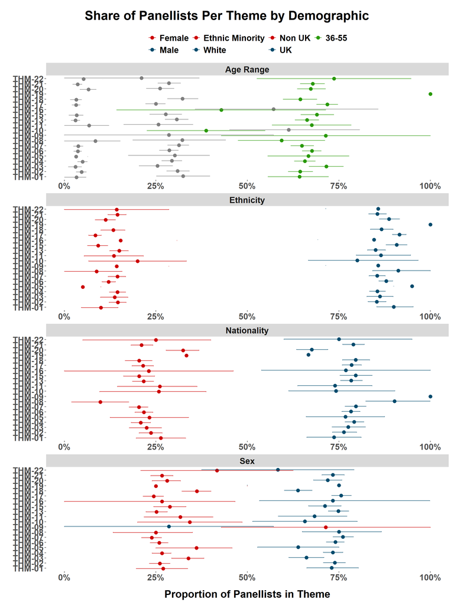

```r
### Panelists
plot_colors <-
  c(
    "Male"= RSSblue,
    "Female"= RSSred,
    "UK"=RSSblue,
    "Non UK"=RSSred,
    "Known Disability"=RSSblue   ,
    "No Known Disability"=RSSred  ,
    "White"=RSSblue  ,
    "Ethnic Minority"=RSSred  ,
    "Unknown"=col_unknown  ,
    "Not Disclosed"=col_notdisclosed  ,
    "35_and_Under" = col_age1,
    "36-55" = col_age3,
    "56_and_Over" = col_age5,
    "Male.White"=RSSblue,
    "Female.White"=RSSred,
    "Male.Ethnic Minority"=RSSlightblue,
    "Female.Ethnic Minority"=RSSgold,
    "Other"=col_other
  )


t3 <- t3 %>% mutate(
  Group = case_when(
    Group == "EthnicityBinary" ~ "Ethnicity",
    Group == "AgeRangeCollapsed" ~ "Age Range",
    Group == "NationalityBinary" ~ "Nationality",
    TRUE ~ Group
  )
)

# Plot the CIs, faceted by Group, colored by Demographic, with dodged positions
fig19.08 <- ggplot(t3 %>% filter(Group != "Disability"), aes(x = Theme, y = Proportion, color = Demographic)) +
  geom_point(position = position_dodge(width = 0.3), size = 3) +
  geom_errorbar(aes(ymin = CI_L, ymax = CI_U),
                position = position_dodge(width = 0.3),
                width = 0.2) +

  facet_wrap(~ Group, ncol = 1, scales = 'free') +
  scale_color_manual(values = plot_colors) +
  labs(title = "Share of Panellists Per Theme by Demographic",
       x = element_blank(),
       y = "Proportion of Panellists in Theme") +
  scale_y_continuous(limits = c(0,1),
                     labels = scales::percent_format(accuracy = 1)) +

  theme(plot.title = element_text(size = 24, hjust = 0.5, margin = margin(b = 15), face = "bold"),
        plot.title.position = "plot",
        axis.title.x = element_text(size = 20, margin = margin(t = 15), face = "bold"),
        axis.title.y = element_text(size = 20, margin = margin(r = 10), face = "bold"),
        plot.margin = margin(t = 20, r = 10, b = 10, l = 10),
        axis.text.x = element_text(size = 16, face = "bold"),
        axis.text.y = element_text(size = 16, face = "bold"),
        legend.position = "top",
        legend.text = element_text(size = 16, face = "bold"),
        legend.title = element_blank(),
        panel.background = element_rect(fill = "white", color = NA),  # Set panel background to white
        plot.background = element_rect(fill = "white", color = NA),   # Set plot background to white
        #panel.grid.major = element_line(color = "gray90"),            # Optional: adjust grid color
        panel.grid.minor = element_blank(),
        strip.text = element_text(size = 16, face = "bold")
    ) +
  coord_flip()

print(fig19.08)
```